# 关于回归分析的拓展？

# 设定一个多元正态分布

期望

```r
#各个维度期望
mean<-c(2, 1, 0)
```

协方差矩阵

```r
#生成相关系数矩阵
myR <- lazyCor(c(0.3,0.5,0.7))
#各个维度方差
mySD <- c(0.7, 1, 5)
#根据各个维度方差与相关系数生成协方差矩阵
(myCov <- lazyCov(Rho = myR, Sd = mySD))
```

```
##      [,1] [,2]  [,3]
## [1,] 0.49 0.21  1.75
## [2,] 0.21 1.00  3.50
## [3,] 1.75 3.50 25.00
```

生成数据示例

```r
# X = mvrnorm(n=n, mu = mean, Sigma = myCov)
# 生成X的维数为n×3
```

# 从回归分析开始：一个X多次抽取Y看系数估计的分布

$X_{n×p}$,$n=200,p=3$

```r
n=200
X=mvrnorm(n=n, mu = mean, Sigma = myCov)  #随机生成一个X
data=as.data.frame(X)
head(data)
```

```
##          V1        V2          V3
## 1 1.9557896 0.1173548  0.06117476
## 2 1.8708668 0.7905561  0.73525524
## 3 0.5796146 0.7474241 -1.30260809
## 4 2.1204930 0.4855418  3.49651660
## 5 3.1270544 2.1839904  4.04870563
## 6 1.8120498 1.0628336  4.22931681
```

随机生成1000次*$y_{n×1}$*并进行回归估计
$$y_{i}=2+5*x_{1i}+2*x_{2i}+1*x_{3i}+\epsilon_{i}$$
$$\epsilon_{i} \sim N(0,1)$$

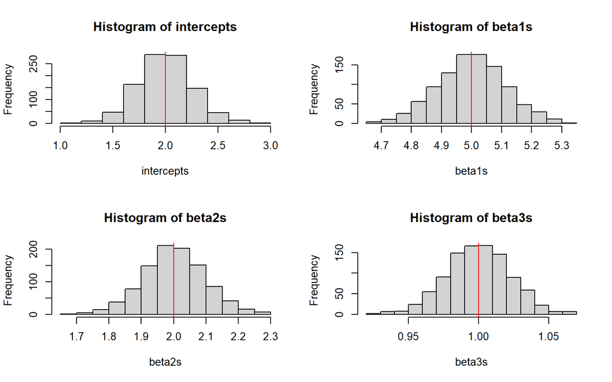

```r
#=============生成1000组Y====================
Ys=list()  #存放每次生成的Y
for(j in 1:1000){
  #Y=2+5*x1+2*x2+1*x3
  Ys[[j]]=2+5*data$V1+2*data$V2+data$V3
  #增加随机误差项
  for(k in 1:n){
    Ys[[j]][k]=Ys[[j]][k]+rnorm(1,0,1)
  }
}

#=============估计=================
intercepts=c() #存放截距项的估计intercept
beta1s=c() #存放X1的系数估计beta1
beta2s=c() #存放X2的系数估计beta2
beta3s=c() #存放X3的系数估计beta3
for(j in 1:1000){
  data_j=cbind(data[,c(1,2,3)],Ys[[j]])
  colnames(data_j)=c("V1","V2","V3","Y")
  fit=lm(Y~V1+V2+V3,data=data_j)
  intercepts=c(intercepts,fit$coefficients[1])
  beta1s=c(beta1s,fit$coefficients[2])
  beta2s=c(beta2s,fit$coefficients[3])
  beta3s=c(beta3s,fit$coefficients[4])
}

#===============================
#画出1000次的系数估计直方图
par(mfrow = c(2,2))
hist(intercepts)
abline(v=2,col='red')
hist(beta1s)
abline(v=5,col='red')
hist(beta2s)
abline(v=2,col='red')
hist(beta3s)
abline(v=1,col='red')
```

> 这里可以验证一下系数估计的方差的模拟值与理论值

> $$\beta=(\beta_{0},\beta_{1},\beta_{2},\beta_{3})^T$$
> $$Var({\beta})=\sigma^2 (X^TX)^{-1}$$
> 其中
> $$X_{n×(p+1)}=\begin{bmatrix}
> {1}&{x_{11}}&{\cdots}&{x_{1p}}\\
> {1}&{x_{21}}&{\cdots}&{x_{2p}}\\
> {\vdots}&{\vdots}&{\ddots}&{\vdots}\\
> {1}&{x_{n1}}&{\cdots}&{x_{np}}\\
> \end{bmatrix}$$

```r
#1000次模拟值（对角线上元素为各个系数估计的模拟方差）
var_inter=var(intercepts)
var_beta1=var(beta1s)
var_beta2=var(beta2s)
var_beta3=var(beta3s)
Var_beta_matrix_simulate = diag(c(var_inter,var_beta1,var_beta2,var_beta3),names = TRUE);Var_beta_matrix_simulate
```

```
##            [,1]       [,2]        [,3]         [,4]
## [1,] 0.06641159 0.00000000 0.000000000 0.0000000000
## [2,] 0.00000000 0.01247547 0.000000000 0.0000000000
## [3,] 0.00000000 0.00000000 0.009219726 0.0000000000
## [4,] 0.00000000 0.00000000 0.000000000 0.0005258396
```

```r
#理论值（对角线上元素为各个系数估计的理论方差）
data_X=as.data.frame(X)
data_X$intercept=1
data_X=data_X%>%select("intercept","V1","V2","V3")
data_X=as.matrix(data_X)
Var_beta_matrix=solve(t(data_X)%*%data_X);Var_beta_matrix
```

```
##              intercept           V1           V2            V3
## intercept  0.069274725 -0.026953765 -0.011130805  0.0033626219
## V1        -0.026953765  0.013275523  0.001058330 -0.0010994286
## V2        -0.011130805  0.001058330  0.008552026 -0.0012205740
## V3         0.003362622 -0.001099429 -0.001220574  0.0004753202
```

# 回归分析之外的：多次从多元分布中生成X，看X的各个维的观测相关性的分布

从这里开始X不限定是一个固定的观测，而是从X生成的角度来进一步思考一些问题。

可以看成与回归分析完全无关的部分。也可以看成把回归分析往前想一步，即回归分析中固定的X并不是一个“设计”来的矩阵，而是从某个特定分布中生成或者抽取的。

讨论X的各个维度的观测相关性与真实相关性的关系。这里用相关系数来作为衡量相关性的指标，也可以用其他的关于X的函数。

这里有一个参数可能会影响到相关系数的分布，就是每次抽取X的大小n，直觉上来看每次抽取的X的大小越大，各个维的相关系数就和多元正态原本的相关系数更接近，这样多次抽取的相关系数的方差就会比较小。

- 先设定n为200

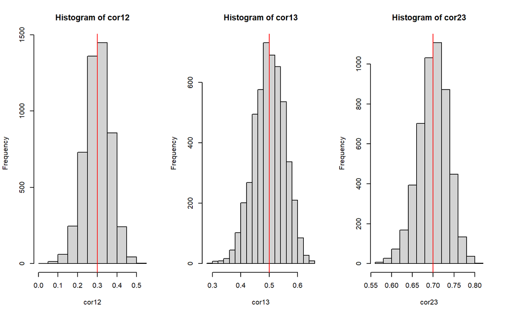

```r
n=200  #每次抽取X的大小，先设定为200

Xs=list()  #存放每次从多元正态分布中生成的X
cor12=c()  #存放每次生成的X的第1、2维的相关系数
cor13=c()  #存放每次生成的X的第1、3维的相关系数
cor23=c()  #存放每次生成的X的第2、3维的相关系数


for (i in 1:5000){  #这里抽取5000次
  set.seed(i)
  Xs[[i]] <- mvrnorm(n=n, mu = mean, Sigma = myCov)
  cor12=c(cor12,cor(Xs[[i]])[1,2])
  cor13=c(cor13,cor(Xs[[i]])[1,3])
  cor23=c(cor23,cor(Xs[[i]])[2,3])
}


par(mfrow = c(1,3))
hist(cor12)
abline(v=0.3,col='red')
hist(cor13)
abline(v=0.5,col='red')
hist(cor23)
abline(v=0.7,col='red')
```

可以看出来，当生成机制中的X的某两维的相关系数为a时，观测的X的这两维的相关系数是a的概率最大。

这里的讨论和回归的关系我觉得可以这么想：

回归分析中说的是X固定，讨论的结果是对X取条件的情况。但是也可以多往前想一步，从数据生成的角度来想，假如x1和x2在多元分布上的相关系数是0.3而不是0，随机生成能观测的数据的时候X里面的x1和x2的观测到的相关系数是0.3而不是0的概率就更大，$\beta$的方差是$\sigma^2 (X^TX)^{-1}$，这个时候估计$\beta$的方差大的可能性就更大。

不过单纯论回归里面其实$\beta$的方差还是观测的X决定的，只不过往前想一步就可以对X各个维度的相关性（从而$\beta$估计的方差$Var(\beta)$）是偶然的还是必定的有一点感觉。因为X的生成机制是未知的，有可能他不是多元正态，各个维度的看起来的相关性可能就是偶然；也有可能他是有相关性的多元正态，随机选择X就表现出相关性；也有可能他是各个维度独立的多元正态或其它分布，但由于我选取X的非随机性导致了X各个维度看起来的相关性。

> 这里有一点不严谨的是相关系数其实和$Var(\beta)$并不是严格正比的，但应该是成正相关的。X矩阵和所有系数的估计量的方差之和的关系是这样的（可以具体到某一个系数估计量的方差吗？）：

> $$tr(Var(\beta))=\sigma^2*tr((X^TX)^{-1})=\sigma^2*\sum_{i=1}^{p}\frac{1}{\lambda_{i}}$$
> $$其中\lambda_{1}\geq\lambda_{2}\geq...\geq\lambda_{p}>0是矩阵X^TX的特征根$$
> 所以如果有某两个维度的相关性很强的话，就会存在一个$\lambda_{i}$接近0，所以$tr(Var(\beta))$就会很大。

> Q：X服从多元正态的话$(X^TX)^{-1}$服从什么是可以求出来的吗？
- 改变n，观察n与相关系数方差的关系

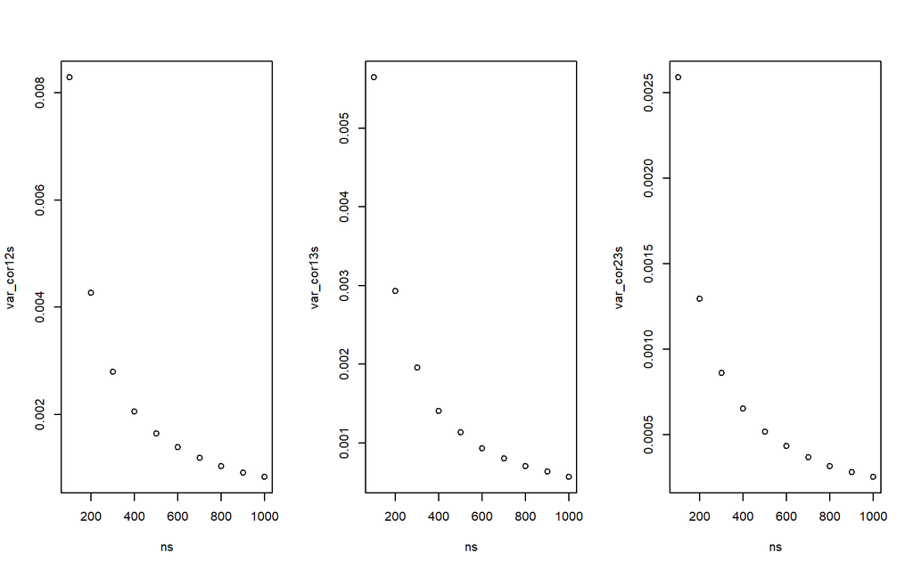

```r
ns=seq(100,1000,100)  #n的取值
var_cor12s=c()  #存放对应n的不同取值，X的第1、2维的相关系数的方差
var_cor13s=c()  #存放对应n的不同取值，X的第1、3维的相关系数的方差
var_cor23s=c()  #存放对应n的不同取值，X的第2、3维的相关系数的方差

for (n in ns){  #对于每个n

  Xs=list()  #存放每次从多元正态分布中生成的X
  cor12=c()
  cor13=c()
  cor23=c()

  for (i in 1:5000){  #这里抽取5000次
    set.seed(i)
    Xs[[i]] <- mvrnorm(n=n, mu = mean, Sigma = myCov)
    cor12=c(cor12,cor(Xs[[i]])[1,2])
    cor13=c(cor13,cor(Xs[[i]])[1,3])
    cor23=c(cor23,cor(Xs[[i]])[2,3])
  }

  var_cor12s=c(var_cor12s,var(cor12))
  var_cor13s=c(var_cor13s,var(cor13))
  var_cor23s=c(var_cor23s,var(cor23))

}

par(mfrow = c(1,3))
plot(ns,var_cor12s)
plot(ns,var_cor13s)
plot(ns,var_cor23s)
```

> Q：这里总觉得可以算出来n与观测的相关系数的方差的式子，但我不会（笑）

# 回归分析之外的：从总体中抽取（生成）X与Y，观察系数估计值的分布情况

这里的设定是：X是从某个分布生成的，Y是X的加权和加上一个随机误差项，同时抽取（生成）一对XY来估计beta，然后看beta的分布。

$$X \sim N(\mu,\Sigma)$$

$$Y|X=X \beta+\epsilon$$

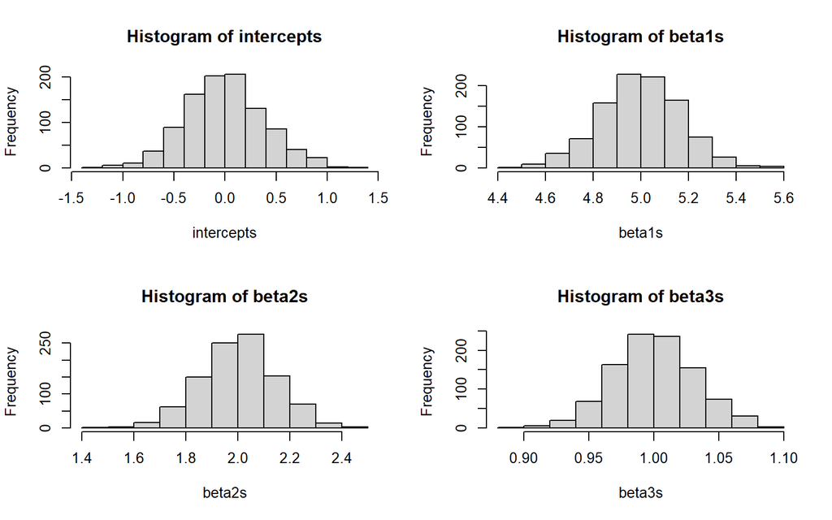

```r
datas=list() #存放每次生成的X与Y
Total=1000
n=100
for (i in 1:Total){
  set.seed(i)
  X_i <- mvrnorm(n=n, mu = mean, Sigma = myCov)
  data_i=as.data.frame(X_i)
  data_i$Y=5*data_i$V1+2*data_i$V2+data_i$V3
  for (j in 1:n){
    data_i$Y[j]=data_i$Y[j]+mvrnorm(n=1, mu=0, Sigma=1)
  }
  datas[[i]]=data_i
}

intercepts=c()
beta1s=c()
beta2s=c()
beta3s=c()
for(i in 1:Total){
  data_fit=datas[[i]]
  fit=lm(Y~.,data=data_fit)
  intercepts=c(intercepts,fit$coefficients[1])
  beta1s=c(beta1s,fit$coefficients[2])
  beta2s=c(beta2s,fit$coefficients[3])
  beta3s=c(beta3s,fit$coefficients[4])
}

#系数估计
par(mfrow = c(2,2))
hist(intercepts)
hist(beta1s)
hist(beta2s)
hist(beta3s)
```

> Q：还是只会simulate不会证:)